# Text Mining With R

Author: Rick Dean

Article date: 2021-01-07

Abstract

The following notes/R scripts were inspired from Chapter 3 of [Text Mining With R](https://www.tidytextmining.com/index.html) by Julia Silge and David Robinson

Note: Functions from the `data.table` and `RtextminerPkg` packages are used in performing many of the following data set operations.

# Analyzing Word and Document Frequency Analysis

## Term frequency

### Term frequency in Jane Austen’s novels

1. Get the Austen books:

```r
ja_books_dt <- data.table::setDT(janeaustenr::austen_books())
str(ja_books_dt)
## Classes 'data.table' and 'data.frame':   73422 obs. of  2 variables:
##  $ text: chr  "SENSE AND SENSIBILITY" "" "by Jane Austen" "" ...
##  $ book: Factor w/ 6 levels "Sense & Sensibility",..: 1 1 1 1 1 1 1 1 1 1 ...
##  - attr(*, ".internal.selfref")=<externalptr>
```

2. Tokenize the books by word:

```r
ja_wrds_lst <- RtextminerPkg::tokenize_text(
  x = ja_books_dt,
  input_col = "text",
  output_col = "word",
  strip_punct = TRUE
)
ja_wrds_dt <- ja_wrds_lst$tokens_dt
head(ja_wrds_dt)
##                   book        word
## 1: Sense & Sensibility       sense
## 2: Sense & Sensibility         and
## 3: Sense & Sensibility sensibility
## 4: Sense & Sensibility          by
## 5: Sense & Sensibility        jane
## 6: Sense & Sensibility      austen
```

3. Get the book totals of words within each book:

```r
ja_book_totals_dt <- ja_wrds_dt[, .(total = .N), by = book]
head(ja_book_totals_dt)
##                   book  total
## 1: Sense & Sensibility 119957
## 2:   Pride & Prejudice 122204
## 3:      Mansfield Park 160460
## 4:                Emma 160996
## 5:    Northanger Abbey  77780
## 6:          Persuasion  83658
```

4. Get the word totals within each book:

```r
ja_wrd_totals_dt <- ja_wrds_dt[, .(n = .N), by = .(book, word)]
head(ja_wrd_totals_dt)
##                   book        word    n
## 1: Sense & Sensibility       sense   32
## 2: Sense & Sensibility         and 3490
## 3: Sense & Sensibility sensibility   10
## 4: Sense & Sensibility          by  749
## 5: Sense & Sensibility        jane    1
## 6: Sense & Sensibility      austen    1
```

```r
data.table::setkey(ja_book_totals_dt, book)
data.table::setkey(ja_wrd_totals_dt, book)
book_words <- ja_wrd_totals_dt[ja_book_totals_dt, nomatch=0][order(-n)]
head(book_words)
##              book word    n  total
## 1: Mansfield Park  the 6206 160460
## 2: Mansfield Park   to 5475 160460
## 3: Mansfield Park  and 5438 160460
## 4:           Emma   to 5239 160996
## 5:           Emma  the 5201 160996
## 6:           Emma  and 4896 160996
```

Note: *book_words* is ordered by *n*.

6. Add a term frequency (*tf* or word proportion) and calculated by dividing *n* by *total*:

```r
book_words[, tf := n/total]
head(book_words)
##              book word    n  total         tf
## 1: Mansfield Park  the 6206 160460 0.03867631
## 2: Mansfield Park   to 5475 160460 0.03412065
## 3: Mansfield Park  and 5438 160460 0.03389007
## 4:           Emma   to 5239 160996 0.03254118
## 5:           Emma  the 5201 160996 0.03230515
## 6:           Emma  and 4896 160996 0.03041069
```

7. Plot a histogram of *tf* for each of the books:

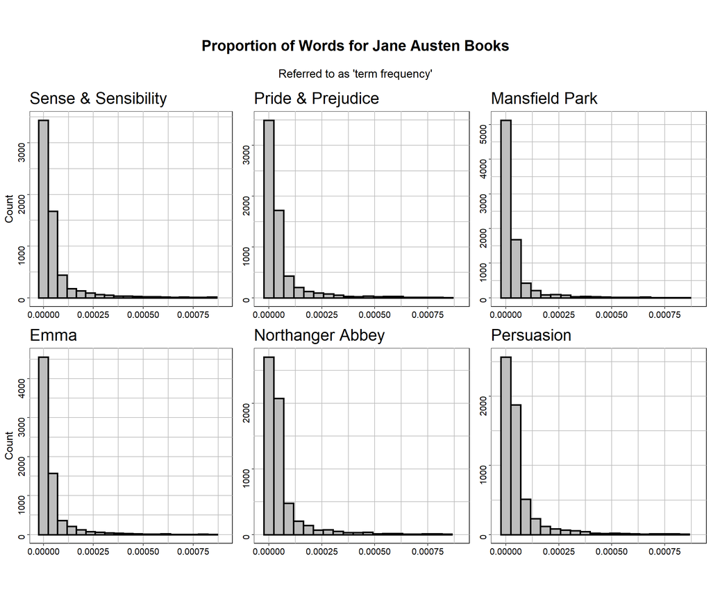

```r
RplotterPkg::multi_histogram_plot(
  df = book_words,
  factor_var = "book",
  factor_x = "tf",
  title = "Proportion of Words for Jane Austen Books",
  subtitle = "Referred to as 'term frequency'",
  columns = 3,
  x_limits = c(NA, 0.0009)
)
```

### Zipf’s Law

> States that the frequency that a word appears is inversely proportional to its rank.
1. Add a *rank* variable to `book_words`. Again note that *book_words* is ordered within each book by *n*.:

```r
book_words[, rank := seq_len(.N), by = book]
head(book_words)
##              book word    n  total         tf rank
## 1: Mansfield Park  the 6206 160460 0.03867631    1
## 2: Mansfield Park   to 5475 160460 0.03412065    2
## 3: Mansfield Park  and 5438 160460 0.03389007    3
## 4:           Emma   to 5239 160996 0.03254118    1
## 5:           Emma  the 5201 160996 0.03230515    2
## 6:           Emma  and 4896 160996 0.03041069    3
```

> Zipf’s law is often visualized by plotting rank on the x-axis and term frequency on the y-axis, on logarithmic scales. Plotting this way, an inversely proportional relationship will have a constant, negative slope.
2. Plot *rank* vs *tf* for each of the books:

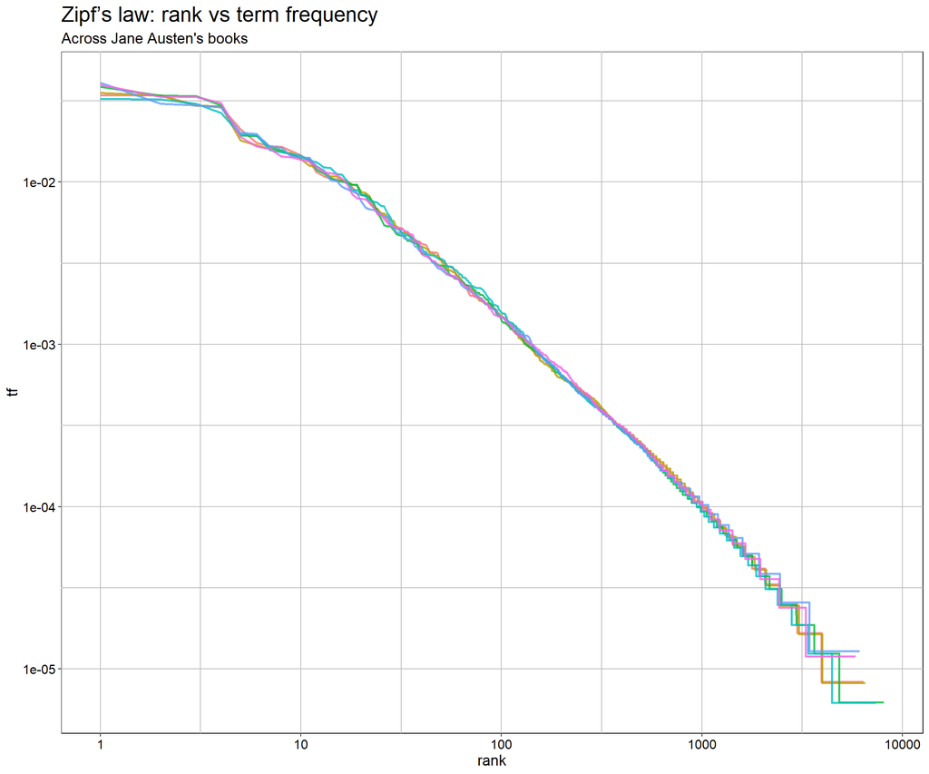

```r
RplotterPkg::create_scatter_plot(
  df = book_words,
  aes_x = "rank",
  aes_y = "tf",
  aes_color = "book",
  title = "Zipf’s law: rank vs term frequency",
  subtitle = "Across Jane Austen's books",
  pts_line_alpha = 0.8,
  pts_size = 1.1,
  x_log10 = TRUE,
  y_log10 = TRUE,
  rot_y_tic_label = T,
  axis_text_size = 12,
  connect = TRUE,
  show_pts = FALSE,
  show_legend = FALSE
)
```

### Power Law

Apply the Power Law to Austen’s *tf*. What is the exponent of the power law for the middle section of the *rank* range.

1. Filter for a subset of the *rank* between 10 and 500:

```r
middle_rank_dt <- book_words[rank > 10 & rank < 500]
```

2. Define a linear model fit between *rank* and *tf*:

```r
middle_rank_lm <- lm(log10(tf) ~ log10(rank), data = middle_rank_dt)
summary(middle_rank_lm)
##
## Call:
## lm(formula = log10(tf) ~ log10(rank), data = middle_rank_dt)
##
## Residuals:
##       Min        1Q    Median        3Q       Max
## -0.118142 -0.010112 -0.002169  0.009284  0.081810
##
## Coefficients:
##               Estimate Std. Error t value Pr(>|t|)
## (Intercept) -0.6225690  0.0022179  -280.7   <2e-16 ***
## log10(rank) -1.1125216  0.0009528 -1167.6   <2e-16 ***
## ---
## Signif. codes:  0 '***' 0.001 '**' 0.01 '*' 0.05 '.' 0.1 ' ' 1
##
## Residual standard error: 0.01838 on 2932 degrees of freedom
## Multiple R-squared:  0.9979, Adjusted R-squared:  0.9979
## F-statistic: 1.363e+06 on 1 and 2932 DF,  p-value: < 2.2e-16
```

3. Plot the fitted power law to the data:

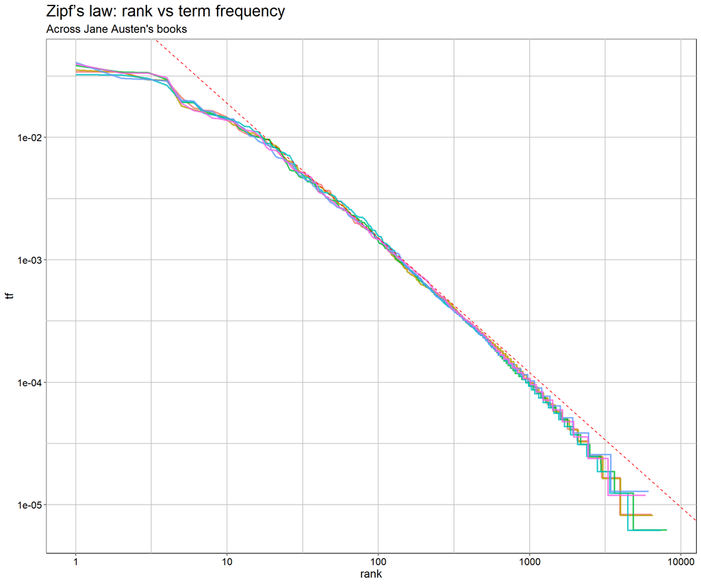

```r
RplotterPkg::create_scatter_plot(
  df = book_words,
  aes_x = "rank",
  aes_y = "tf",
  aes_color = "book",
  title = "Zipf’s law: rank vs term frequency",
  subtitle = "Across Jane Austen's books",
  pts_line_alpha = 0.8,
  pts_size = 1.1,
  x_log10 = TRUE,
  y_log10 = TRUE,
  rot_y_tic_label = T,
  axis_text_size = 12,
  connect = TRUE,
  show_pts = FALSE,
  show_legend = FALSE
) + ggplot2::geom_abline(intercept = -0.62, slope = -1.1, color = "red", linetype = 2)
```

The deviations at high rank with the Power Law giving a higher *tf* is not uncommon. Austen at the lower rank with more frequent words seems to be lower than usual.

## Term Frequency-Inverse Document Frequency(tf-idf)

> The idea of tf-idf is to find the important words for the content of each document by decreasing the weight for commonly used words and increasing the weight for words that are not used very much in a collection or corpus of documents…

### The tidytext::bind_tf_idf function.

We can use `tidytext::bind_tf_idf()` to calculate the tf-idf. The only requirement is that the documents are tokenized and we can find the count of each word, in each book. We have those numbers in column *n* of *book_words* from above.

1. Looking again at *book_words*:

```r
head(book_words)
##              book word    n  total         tf rank
## 1: Mansfield Park  the 6206 160460 0.03867631    1
## 2: Mansfield Park   to 5475 160460 0.03412065    2
## 3: Mansfield Park  and 5438 160460 0.03389007    3
## 4:           Emma   to 5239 160996 0.03254118    1
## 5:           Emma  the 5201 160996 0.03230515    2
## 6:           Emma  and 4896 160996 0.03041069    3
```

2. Apply `tidytext::bind_tf_idf(word, book, n)` which will bind the tf_idf as a column to *book_words*:

```r
book_words <- book_words %>%
    tidytext::bind_tf_idf(term = word, document = book, n = n)
head(book_words)
##              book word    n  total         tf rank idf tf_idf
## 1: Mansfield Park  the 6206 160460 0.03867631    1   0      0
## 2: Mansfield Park   to 5475 160460 0.03412065    2   0      0
## 3: Mansfield Park  and 5438 160460 0.03389007    3   0      0
## 4:           Emma   to 5239 160996 0.03254118    1   0      0
## 5:           Emma  the 5201 160996 0.03230515    2   0      0
## 6:           Emma  and 4896 160996 0.03041069    3   0      0
```

Note that “idf” (inverse document frequency) and “tf_idf” are 0 for extremely common words. The “idf” will be higher for words that occur in fewer of the documents.

Reverse the order of book_words and look at the other end of “tf_idf”. Also remove variable “total”.

```r
book_words <- book_words[, !c("total")][order(-tf_idf)]
head(book_words)
##                   book     word   n          tf rank      idf      tf_idf
## 1: Sense & Sensibility   elinor 623 0.005193528   32 1.791759 0.009305552
## 2: Sense & Sensibility marianne 492 0.004101470   42 1.791759 0.007348847
## 3:      Mansfield Park crawford 493 0.003072417   49 1.791759 0.005505032
## 4:   Pride & Prejudice    darcy 373 0.003052273   53 1.791759 0.005468939
## 5:          Persuasion   elliot 254 0.003036171   49 1.791759 0.005440088
## 6:                Emma     emma 786 0.004882109   32 1.098612 0.005363545
```

### The RtextminerPkg::get_tf_idf() function

`RtextminerPkg::get_tf_idf()` is a data.table based approach to computing the tf-idf. Its only argument requirement is a data frame holding a collection of documents–it will handle the word tokenization. There should be a column for the document id and a second column for the text – not unlike the Jane Austen collection we’ve been working with.

1. Looking at the collection again we have 73422 rows of text under the text column and a column that identifies the book:

```r
ja_books <- janeaustenr::austen_books()
head(ja_books)
## # A tibble: 6 x 2
##   text                    book
##   <chr>                   <fct>
## 1 "SENSE AND SENSIBILITY" Sense & Sensibility
## 2 ""                      Sense & Sensibility
## 3 "by Jane Austen"        Sense & Sensibility
## 4 ""                      Sense & Sensibility
## 5 "(1811)"                Sense & Sensibility
## 6 ""                      Sense & Sensibility
```

2. Call `RtextminerPkg::get_tf_idf()`:

```r
tf_idf_dt <- RtextminerPkg::get_tf_idf(
  x = ja_books,
  feature_id = "book",
  feature_text = "text")
head(tf_idf_dt)
##             feature_id     word token_n feature_n          tf      idf
## 1: Sense & Sensibility   elinor     623    143408 0.004344249 1.791759
## 2: Sense & Sensibility marianne     492    143408 0.003430771 1.791759
## 3:      Mansfield Park crawford     493    188284 0.002618385 1.791759
## 4:          Persuasion   elliot     254     98181 0.002587059 1.791759
## 5:   Pride & Prejudice    darcy     373    144927 0.002573710 1.791759
## 6:                Emma     emma     786    197537 0.003979001 1.098612
##         tf_idf
## 1: 0.007783849
## 2: 0.006147116
## 3: 0.004691516
## 4: 0.004635387
## 5: 0.004611468
## 6: 0.004371380
```

### Plot tf_idf values for 15 words across the novels

All the words are proper nouns. None of them occur in all the novels, and they are important, characteristic words for each of their corresponding text.

1. For plotting select the top 15 “word” values:

```r
words_tf_idf <- tf_idf_dt[, setorder(.SD, -tf_idf)[1:15], by = feature_id]
head(words_tf_idf)
##             feature_id       word token_n feature_n           tf      idf
## 1: Sense & Sensibility     elinor     623    143408 0.0043442486 1.791759
## 2: Sense & Sensibility   marianne     492    143408 0.0034307709 1.791759
## 3: Sense & Sensibility   dashwood     231    143408 0.0016107888 1.791759
## 4: Sense & Sensibility   jennings     199    143408 0.0013876492 1.791759
## 5: Sense & Sensibility willoughby     181    143408 0.0012621332 1.791759
## 6: Sense & Sensibility    brandon     119    143408 0.0008298003 1.791759
##         tf_idf
## 1: 0.007783849
## 2: 0.006147116
## 3: 0.002886146
## 4: 0.002486334
## 5: 0.002261439
## 6: 0.001486803
```

2. Show a bar plot of the tf_idf values for 15 words across the novels.

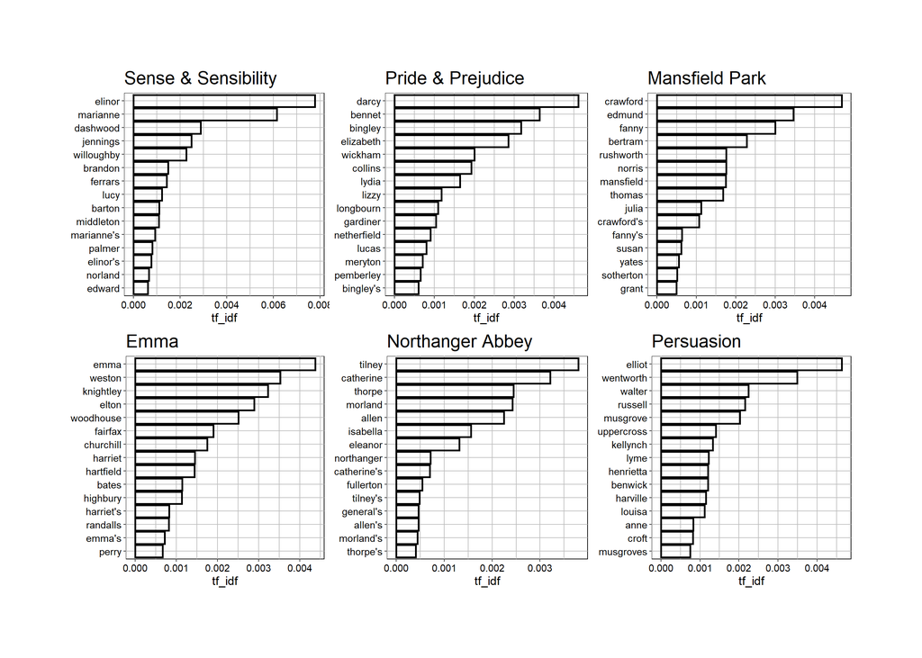

```r
tf_idf_plot <- RplotterPkg::multi_bar_plot(
    df = words_tf_idf,
    factor_var = "feature_id",
    factor_x = "word",
    columns = 3,
    aes_y = "tf_idf",
    y_titles = rep("tf_idf",6),
    rot_y_tic_label = TRUE,
    do_coord_flip = TRUE,
    order_bars = "asc"
)
```

## Corpus of physics texts

Look at a set set non-fiction physics documents and evaluate the tf-idf for important words.

1. Download the physics:

```r
physics_books <- gutenberg_download(c(37729, 14725, 13476, 30155), meta_fields = "author")
```

2. Compute the tf-idf with a set of stop words:

```r
stop_words <- c("eq", "co", "rc", "ac", "ak", "bn", "fig", "file", "cg", "cb", "cm", "_k", "_k_", "_x")
tf_idf_physics_dt <- RtextminerPkg::get_tf_idf(
  x = physics_books,
  feature_id = "author",
  feature_text = "text",
  stopwords = stop_words,
  lowercase = T,
  strip_numeric = T,
  strip_punct = T)
head(tf_idf_physics_dt)
##          feature_id       word token_n feature_n          tf       idf
## 1: Einstein, Albert relativity     193     30713 0.006283984 1.3862944
## 2:    Tesla, Nikola       bulb     171     39142 0.004368709 1.3862944
## 3: Galilei, Galileo      water     828     39870 0.020767494 0.2876821
## 4:    Tesla, Nikola       coil     166     39142 0.004240969 1.3862944
## 5:    Tesla, Nikola       wire     133     39142 0.003397885 1.3862944
## 6: Galilei, Galileo       hath     132     39870 0.003310760 1.3862944
##         tf_idf
## 1: 0.008711452
## 2: 0.006056316
## 3: 0.005974436
## 4: 0.005879231
## 5: 0.004710468
## 6: 0.004589688
```

3. For plotting select the top 15 “word” values:

```r
tf_idf_15_physics_dt <- tf_idf_physics_dt[, setorder(.SD, -tf_idf)[1:15], by = feature_id]
head(tf_idf_15_physics_dt)
##          feature_id          word token_n feature_n          tf       idf
## 1: Einstein, Albert    relativity     193     30713 0.006283984 1.3862944
## 2: Einstein, Albert        theory     181     30713 0.005893270 0.6931472
## 3: Einstein, Albert gravitational      87     30713 0.002832677 1.3862944
## 4: Einstein, Albert     ordinates      65     30713 0.002116368 1.3862944
## 5: Einstein, Albert      ordinate      60     30713 0.001953570 1.3862944
## 6: Einstein, Albert     continuum      54     30713 0.001758213 1.3862944
##         tf_idf
## 1: 0.008711452
## 2: 0.004084903
## 3: 0.003926924
## 4: 0.002933909
## 5: 0.002708223
## 6: 0.002437401
```

4. Show a bar plot of the tf_idf values for 15 words across the authors.

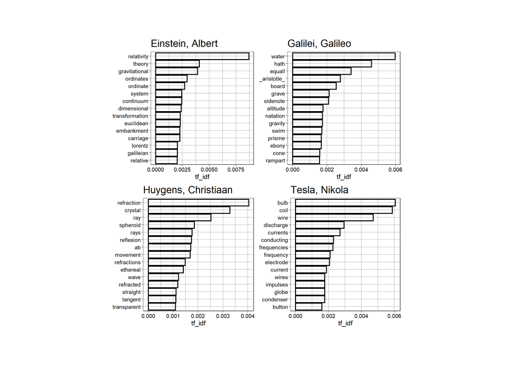

```r
tf_idf_physics_plot <- RplotterPkg::multi_bar_plot(
    df = tf_idf_15_physics_dt,
    factor_var = "feature_id",
    factor_x = "word",
    columns = 2,
    aes_y = "tf_idf",
    y_titles = rep("tf_idf",4),
    rot_y_tic_label = TRUE,
    do_coord_flip = TRUE,
    order_bars = "asc"
)
```